# Project: No-show appointments

- 1. Introduction
- 2. Data Wrangling
- 3. Data Cleaning
- 4. Exploratory Data Analysis
- 5. Conclusions

## 1. Introduction

If a person makes a doctor's appointment, receives instructions and does not turn up, who is at fault? A no-show appointment leads to missed opportunities for other patients and an inefficient use of doctors and nurses.

The purpose of this task is to determine whether we can predict when a no-show appointment will occur.

The data set contains information on 110,527 medical appointments from different parts of Brazil and focuses on the question of whether or not patients show up for their appointments and how the attributes that are about to be presented influence this probability.

The dataset contains 14 attributes:

Potential questions:

- What gender (M/F) is most likely to not attend an appointment?
- How does age affect whether a patient will turn up to an appointment?
- What impact does the location of the hospital have on appointment attendance?
- How does the number of days between making an appointment to the scheduled date, affect attendance?
- How effective are SMS reminders?
- How does day of the week affect attendance?

## 2. Data Wrangling

#### Initial setup:

```python
# Importing required packages
import pandas as pd
import numpy as np
import matplotlib.pyplot as plt
import seaborn as sns
%matplotlib inline
```

#### Load data and print out a few lines:

```python
# Loading data from the csv file:
df = pd.read_csv('noshowappointments.csv')
df.head()
```

|  | PatientId | AppointmentID | Gender | ScheduledDay | AppointmentDay | Age | Neighbourhood | Scholarship | Hipertension | Diabetes | Alcoholism | Handcap | SMS_received | No-show |
| --- | --- | --- | --- | --- | --- | --- | --- | --- | --- | --- | --- | --- | --- | --- |
| 0 | 2.987250e+13 | 5642903 | F | 2016-04-29T18:38:08Z | 2016-04-29T00:00:00Z | 62 | JARDIM DA PENHA | 0 | 1 | 0 | 0 | 0 | 0 | No |
| 1 | 5.589978e+14 | 5642503 | M | 2016-04-29T16:08:27Z | 2016-04-29T00:00:00Z | 56 | JARDIM DA PENHA | 0 | 0 | 0 | 0 | 0 | 0 | No |
| 2 | 4.262962e+12 | 5642549 | F | 2016-04-29T16:19:04Z | 2016-04-29T00:00:00Z | 62 | MATA DA PRAIA | 0 | 0 | 0 | 0 | 0 | 0 | No |
| 3 | 8.679512e+11 | 5642828 | F | 2016-04-29T17:29:31Z | 2016-04-29T00:00:00Z | 8 | PONTAL DE CAMBURI | 0 | 0 | 0 | 0 | 0 | 0 | No |
| 4 | 8.841186e+12 | 5642494 | F | 2016-04-29T16:07:23Z | 2016-04-29T00:00:00Z | 56 | JARDIM DA PENHA | 0 | 1 | 1 | 0 | 0 | 0 | No |

- Observation: While minor, 'hipertension' and 'Handcap' are spelt incorrectly. No-Show will be replaced with 'No_show'.
- Action: As part of data cleaning, correct the spelling of these.

#### Review the shape of the table:

```python
df.shape
print("The database has {} rows and {} columns".format(df.shape[0], df.shape[1]))
```

```
The database has 110527 rows and 14 columns
```

#### Review the data types of columns:

```python
df.info()
```

```
<class 'pandas.core.frame.DataFrame'>
RangeIndex: 110527 entries, 0 to 110526
Data columns (total 14 columns):
 #   Column          Non-Null Count   Dtype
---  ------          --------------   -----
 0   PatientId       110527 non-null  float64
 1   AppointmentID   110527 non-null  int64
 2   Gender          110527 non-null  object
 3   ScheduledDay    110527 non-null  object
 4   AppointmentDay  110527 non-null  object
 5   Age             110527 non-null  int64
 6   Neighbourhood   110527 non-null  object
 7   Scholarship     110527 non-null  int64
 8   Hipertension    110527 non-null  int64
 9   Diabetes        110527 non-null  int64
 10  Alcoholism      110527 non-null  int64
 11  Handcap         110527 non-null  int64
 12  SMS_received    110527 non-null  int64
 13  No-show         110527 non-null  object
dtypes: float64(1), int64(8), object(5)
memory usage: 11.8+ MB
```

- Observation: I would expect the 'Scheduled Day' and 'AppointmentDay' to be of data type 'datetime' rather than a string.
- Action: As part of the data cleaning, change the dtype from string to datetime

#### Review for any duplicate rows:

```python
# Reviewing for duplicates
df.duplicated().sum()
```

```
0
```

- Observation: No duplicate rows exist in the dataset

#### Review for any rows with null values:

```python
# Reviewing for null values:
df.isnull().sum()
```

```
PatientId         0
AppointmentID     0
Gender            0
ScheduledDay      0
AppointmentDay    0
Age               0
Neighbourhood     0
Scholarship       0
Hipertension      0
Diabetes          0
Alcoholism        0
Handcap           0
SMS_received      0
No-show           0
dtype: int64
```

- Observation: There are no rows will null values.

#### Review the number of unique values of each of the columns:

```python
# Reviewing the number of unique values of each of the columns.
df.nunique()
```

```
PatientId          62299
AppointmentID     110527
Gender                 2
ScheduledDay      103549
AppointmentDay        27
Age                  104
Neighbourhood         81
Scholarship            2
Hipertension           2
Diabetes               2
Alcoholism             2
Handcap                5
SMS_received           2
No-show                2
dtype: int64
```

- Observation: From the above, it looks like there are duplicated Patient Id's. Let's look at this further below.

```python
# Number of Patient Id's that are duplicated:

df['PatientId'].duplicated().sum()
```

```
48228
```

```python
# Check out the unique values of age to see if there is anything that does not look right:
age_unique_sorted = sorted(df['Age'].unique())
print(age_unique_sorted)
```

```
[-1, 0, 1, 2, 3, 4, 5, 6, 7, 8, 9, 10, 11, 12, 13, 14, 15, 16, 17, 18, 19, 20, 21, 22, 23, 24, 25, 26, 27, 28, 29, 30, 31, 32, 33, 34, 35, 36, 37, 38, 39, 40, 41, 42, 43, 44, 45, 46, 47, 48, 49, 50, 51, 52, 53, 54, 55, 56, 57, 58, 59, 60, 61, 62, 63, 64, 65, 66, 67, 68, 69, 70, 71, 72, 73, 74, 75, 7…
```

- Observation: There is an age of -1 which is not possible. There is also an age of 115, which could be possible.
- Action: To remove the -1 age.

```python
# Review age groups:
df['Age'].describe()
```

```
count    110527.000000
mean         37.088874
std          23.110205
min          -1.000000
25%          18.000000
50%          37.000000
75%          55.000000
max         115.000000
Name: Age, dtype: float64
```

### Key Findings and Observations from the Data Wrangling process:

- The no show appointments dataset contains 110,527 records with 14 columns.
- Two column headers contain spelling mistakes - these are 'Hipertension' and 'Handcap'.
- ScheduledDay and AppointmentDay columns are of a string datatype, however datetime format would be more appropriate.
- There are no rows with duplicate data.
- There are no rows will null values.
- There are 48,228 duplicated Patient Id's. This suggests that patients can make more than 1 appointment.
- Of the 104 unique age values, there is an age of -1 which does not appear to be correct.
- As there is such a wide range of ages, we will create bin edges that will be used to "cut" the data into groups.
- Appointment ID and Patient ID columns do not appear to add much value, these can be removed.
- The focus of this analysis will be on all other remaining columns.

## 3. Data Cleaning

#### Correct spelling of column headings

```python
# Rename column headings from 'Hipertension' and 'Handcap' to 'Hypertension' and 'Handicap' respectively.
# Also change No-show to No_show.
df.rename(columns={'Hipertension': 'Hypertension', 'Handcap': 'Handicap', 'No-show': 'No_show'}, inplace=True)
```

```python
df.head()
```

|  | PatientId | AppointmentID | Gender | ScheduledDay | AppointmentDay | Age | Neighbourhood | Scholarship | Hypertension | Diabetes | Alcoholism | Handicap | SMS_received | No_show |
| --- | --- | --- | --- | --- | --- | --- | --- | --- | --- | --- | --- | --- | --- | --- |
| 0 | 2.987250e+13 | 5642903 | F | 2016-04-29T18:38:08Z | 2016-04-29T00:00:00Z | 62 | JARDIM DA PENHA | 0 | 1 | 0 | 0 | 0 | 0 | No |
| 1 | 5.589978e+14 | 5642503 | M | 2016-04-29T16:08:27Z | 2016-04-29T00:00:00Z | 56 | JARDIM DA PENHA | 0 | 0 | 0 | 0 | 0 | 0 | No |
| 2 | 4.262962e+12 | 5642549 | F | 2016-04-29T16:19:04Z | 2016-04-29T00:00:00Z | 62 | MATA DA PRAIA | 0 | 0 | 0 | 0 | 0 | 0 | No |
| 3 | 8.679512e+11 | 5642828 | F | 2016-04-29T17:29:31Z | 2016-04-29T00:00:00Z | 8 | PONTAL DE CAMBURI | 0 | 0 | 0 | 0 | 0 | 0 | No |
| 4 | 8.841186e+12 | 5642494 | F | 2016-04-29T16:07:23Z | 2016-04-29T00:00:00Z | 56 | JARDIM DA PENHA | 0 | 1 | 1 | 0 | 0 | 0 | No |

#### String to datetime format:

```python
# Changing the date format for Scheduled Day to datetime format
df['ScheduledDay'] = pd.to_datetime(df['ScheduledDay'])
```

```python
# splitting out the month and the day of the week into separate columns:
df['Scheduled_Day_month'] = df['ScheduledDay'].dt.month
df['Scheduled_Day_dow'] = df['ScheduledDay'].dt.day_name()
```

```python
# splitting out the hour from the time into a separate columns:
df['Scheduled_Day_hour']=df['ScheduledDay'].dt.hour
```

```python
# Checking that the above has occured correctly:
df.head(1)
```

|  | PatientId | AppointmentID | Gender | ScheduledDay | AppointmentDay | Age | Neighbourhood | Scholarship | Hypertension | Diabetes | Alcoholism | Handicap | SMS_received | No_show | Scheduled_Day_month | Scheduled_Day_dow | Scheduled_Day_hour |
| --- | --- | --- | --- | --- | --- | --- | --- | --- | --- | --- | --- | --- | --- | --- | --- | --- | --- |
| 0 | 2.987250e+13 | 5642903 | F | 2016-04-29 18:38:08+00:00 | 2016-04-29T00:00:00Z | 62 | JARDIM DA PENHA | 0 | 1 | 0 | 0 | 0 | 0 | No | 4 | Friday | 18 |

```python
# Changing the date format for Appointment Day to datetime format
df['AppointmentDay'] = pd.to_datetime(df['AppointmentDay'])
```

```python
#Splitting out the month and day of the week into separate columns:
df['Appointment_Day_month'] = df['AppointmentDay'].dt.month
df['Appointment_Day_dow'] = df['AppointmentDay'].dt.day_name()
```

```python
# Checking the above has occured correctly:
df.head(1)
```

|  | PatientId | AppointmentID | Gender | ScheduledDay | AppointmentDay | Age | Neighbourhood | Scholarship | Hypertension | Diabetes | Alcoholism | Handicap | SMS_received | No_show | Scheduled_Day_month | Scheduled_Day_dow | Scheduled_Day_hour | Appointment_Day_month | Appointment_Day_dow |
| --- | --- | --- | --- | --- | --- | --- | --- | --- | --- | --- | --- | --- | --- | --- | --- | --- | --- | --- | --- |
| 0 | 2.987250e+13 | 5642903 | F | 2016-04-29 18:38:08+00:00 | 2016-04-29 00:00:00+00:00 | 62 | JARDIM DA PENHA | 0 | 1 | 0 | 0 | 0 | 0 | No | 4 | Friday | 18 | 4 | Friday |

#### Number of days from appointment day to scheduled day:

```python
# Calculate the number of days a patient has to wait to see a doctor:
df['Num_of_days']=(df.AppointmentDay - df.ScheduledDay).abs().dt.days
```

```python
# Confirm changes:
df.head()
```

|  | PatientId | AppointmentID | Gender | ScheduledDay | AppointmentDay | Age | Neighbourhood | Scholarship | Hypertension | Diabetes | Alcoholism | Handicap | SMS_received | No_show | Scheduled_Day_month | Scheduled_Day_dow | Scheduled_Day_hour | Appointment_Day_month | Appointment_Day_dow | Num_of_days |
| --- | --- | --- | --- | --- | --- | --- | --- | --- | --- | --- | --- | --- | --- | --- | --- | --- | --- | --- | --- | --- |
| 0 | 2.987250e+13 | 5642903 | F | 2016-04-29 18:38:08+00:00 | 2016-04-29 00:00:00+00:00 | 62 | JARDIM DA PENHA | 0 | 1 | 0 | 0 | 0 | 0 | No | 4 | Friday | 18 | 4 | Friday | 0 |
| 1 | 5.589978e+14 | 5642503 | M | 2016-04-29 16:08:27+00:00 | 2016-04-29 00:00:00+00:00 | 56 | JARDIM DA PENHA | 0 | 0 | 0 | 0 | 0 | 0 | No | 4 | Friday | 16 | 4 | Friday | 0 |
| 2 | 4.262962e+12 | 5642549 | F | 2016-04-29 16:19:04+00:00 | 2016-04-29 00:00:00+00:00 | 62 | MATA DA PRAIA | 0 | 0 | 0 | 0 | 0 | 0 | No | 4 | Friday | 16 | 4 | Friday | 0 |
| 3 | 8.679512e+11 | 5642828 | F | 2016-04-29 17:29:31+00:00 | 2016-04-29 00:00:00+00:00 | 8 | PONTAL DE CAMBURI | 0 | 0 | 0 | 0 | 0 | 0 | No | 4 | Friday | 17 | 4 | Friday | 0 |
| 4 | 8.841186e+12 | 5642494 | F | 2016-04-29 16:07:23+00:00 | 2016-04-29 00:00:00+00:00 | 56 | JARDIM DA PENHA | 0 | 1 | 1 | 0 | 0 | 0 | No | 4 | Friday | 16 | 4 | Friday | 0 |

#### Of the number of days just calculated, create bins/groups:

```python
day_edges = [-1, 0, 7, 14, 30, 90, 180]
day_labels = ['same_day', '1_week', '2_weeks', '1_month', '3_months', '6_months']
df['Num_of_days_groups'] = pd.cut(df['Num_of_days'], day_edges, labels=day_labels)
```

```python
# Confirm changes:
df.head()
```

|  | PatientId | AppointmentID | Gender | ScheduledDay | AppointmentDay | Age | Neighbourhood | Scholarship | Hypertension | Diabetes | ... | Handicap | SMS_received | No_show | Scheduled_Day_month | Scheduled_Day_dow | Scheduled_Day_hour | Appointment_Day_month | Appointment_Day_dow | Num_of_days | Num_of_days_groups |
| --- | --- | --- | --- | --- | --- | --- | --- | --- | --- | --- | --- | --- | --- | --- | --- | --- | --- | --- | --- | --- | --- |
| 0 | 2.987250e+13 | 5642903 | F | 2016-04-29 18:38:08+00:00 | 2016-04-29 00:00:00+00:00 | 62 | JARDIM DA PENHA | 0 | 1 | 0 | ... | 0 | 0 | No | 4 | Friday | 18 | 4 | Friday | 0 | same_day |
| 1 | 5.589978e+14 | 5642503 | M | 2016-04-29 16:08:27+00:00 | 2016-04-29 00:00:00+00:00 | 56 | JARDIM DA PENHA | 0 | 0 | 0 | ... | 0 | 0 | No | 4 | Friday | 16 | 4 | Friday | 0 | same_day |
| 2 | 4.262962e+12 | 5642549 | F | 2016-04-29 16:19:04+00:00 | 2016-04-29 00:00:00+00:00 | 62 | MATA DA PRAIA | 0 | 0 | 0 | ... | 0 | 0 | No | 4 | Friday | 16 | 4 | Friday | 0 | same_day |
| 3 | 8.679512e+11 | 5642828 | F | 2016-04-29 17:29:31+00:00 | 2016-04-29 00:00:00+00:00 | 8 | PONTAL DE CAMBURI | 0 | 0 | 0 | ... | 0 | 0 | No | 4 | Friday | 17 | 4 | Friday | 0 | same_day |
| 4 | 8.841186e+12 | 5642494 | F | 2016-04-29 16:07:23+00:00 | 2016-04-29 00:00:00+00:00 | 56 | JARDIM DA PENHA | 0 | 1 | 1 | ... | 0 | 0 | No | 4 | Friday | 16 | 4 | Friday | 0 | same_day |

5 rows × 21 columns

#### Remove row with -1 Age

```python
#Find the row with the -1 Age:
df.query('Age == -1')
```

|  | PatientId | AppointmentID | Gender | ScheduledDay | AppointmentDay | Age | Neighbourhood | Scholarship | Hypertension | Diabetes | ... | Handicap | SMS_received | No_show | Scheduled_Day_month | Scheduled_Day_dow | Scheduled_Day_hour | Appointment_Day_month | Appointment_Day_dow | Num_of_days | Num_of_days_groups |
| --- | --- | --- | --- | --- | --- | --- | --- | --- | --- | --- | --- | --- | --- | --- | --- | --- | --- | --- | --- | --- | --- |
| 99832 | 4.659432e+14 | 5775010 | F | 2016-06-06 08:58:13+00:00 | 2016-06-06 00:00:00+00:00 | -1 | ROMÃO | 0 | 0 | 0 | ... | 0 | 0 | No | 6 | Monday | 8 | 6 | Monday | 0 | same_day |

1 rows × 21 columns

```python
# Remove the row with -1:
df.drop(df.query('Age == -1').index, axis = 0, inplace=True)
```

```python
# Confirm changes:
df.query("Age ==-1")
```

|  | PatientId | AppointmentID | Gender | ScheduledDay | AppointmentDay | Age | Neighbourhood | Scholarship | Hypertension | Diabetes | ... | Handicap | SMS_received | No_show | Scheduled_Day_month | Scheduled_Day_dow | Scheduled_Day_hour | Appointment_Day_month | Appointment_Day_dow | Num_of_days | Num_of_days_groups |
| --- | --- | --- | --- | --- | --- | --- | --- | --- | --- | --- | --- | --- | --- | --- | --- | --- | --- | --- | --- | --- | --- |

0 rows × 21 columns

#### Create bins of different age groups:

```python
# Create different groups:
bin_edges = [-1, 18, 36, 56, 76, 116]
bin_names = ['0-17', '18-35', '36-55', '56-75', '76+']
df['Age_groups'] = pd.cut(df['Age'], bin_edges, labels = bin_names)
```

```python
df.head()
```

|  | PatientId | AppointmentID | Gender | ScheduledDay | AppointmentDay | Age | Neighbourhood | Scholarship | Hypertension | Diabetes | ... | SMS_received | No_show | Scheduled_Day_month | Scheduled_Day_dow | Scheduled_Day_hour | Appointment_Day_month | Appointment_Day_dow | Num_of_days | Num_of_days_groups | Age_groups |
| --- | --- | --- | --- | --- | --- | --- | --- | --- | --- | --- | --- | --- | --- | --- | --- | --- | --- | --- | --- | --- | --- |
| 0 | 2.987250e+13 | 5642903 | F | 2016-04-29 18:38:08+00:00 | 2016-04-29 00:00:00+00:00 | 62 | JARDIM DA PENHA | 0 | 1 | 0 | ... | 0 | No | 4 | Friday | 18 | 4 | Friday | 0 | same_day | 56-75 |
| 1 | 5.589978e+14 | 5642503 | M | 2016-04-29 16:08:27+00:00 | 2016-04-29 00:00:00+00:00 | 56 | JARDIM DA PENHA | 0 | 0 | 0 | ... | 0 | No | 4 | Friday | 16 | 4 | Friday | 0 | same_day | 36-55 |
| 2 | 4.262962e+12 | 5642549 | F | 2016-04-29 16:19:04+00:00 | 2016-04-29 00:00:00+00:00 | 62 | MATA DA PRAIA | 0 | 0 | 0 | ... | 0 | No | 4 | Friday | 16 | 4 | Friday | 0 | same_day | 56-75 |
| 3 | 8.679512e+11 | 5642828 | F | 2016-04-29 17:29:31+00:00 | 2016-04-29 00:00:00+00:00 | 8 | PONTAL DE CAMBURI | 0 | 0 | 0 | ... | 0 | No | 4 | Friday | 17 | 4 | Friday | 0 | same_day | 0-17 |
| 4 | 8.841186e+12 | 5642494 | F | 2016-04-29 16:07:23+00:00 | 2016-04-29 00:00:00+00:00 | 56 | JARDIM DA PENHA | 0 | 1 | 1 | ... | 0 | No | 4 | Friday | 16 | 4 | Friday | 0 | same_day | 36-55 |

5 rows × 22 columns

#### Drop columns 'PatientId' and 'AppointmentID'

```python
# Drop columns:
df.drop(['PatientId', 'AppointmentID'], axis=1, inplace=True)
```

```python
# Confirm changes:
df.head()
```

|  | Gender | ScheduledDay | AppointmentDay | Age | Neighbourhood | Scholarship | Hypertension | Diabetes | Alcoholism | Handicap | SMS_received | No_show | Scheduled_Day_month | Scheduled_Day_dow | Scheduled_Day_hour | Appointment_Day_month | Appointment_Day_dow | Num_of_days | Num_of_days_groups | Age_groups |
| --- | --- | --- | --- | --- | --- | --- | --- | --- | --- | --- | --- | --- | --- | --- | --- | --- | --- | --- | --- | --- |
| 0 | F | 2016-04-29 18:38:08+00:00 | 2016-04-29 00:00:00+00:00 | 62 | JARDIM DA PENHA | 0 | 1 | 0 | 0 | 0 | 0 | No | 4 | Friday | 18 | 4 | Friday | 0 | same_day | 56-75 |
| 1 | M | 2016-04-29 16:08:27+00:00 | 2016-04-29 00:00:00+00:00 | 56 | JARDIM DA PENHA | 0 | 0 | 0 | 0 | 0 | 0 | No | 4 | Friday | 16 | 4 | Friday | 0 | same_day | 36-55 |
| 2 | F | 2016-04-29 16:19:04+00:00 | 2016-04-29 00:00:00+00:00 | 62 | MATA DA PRAIA | 0 | 0 | 0 | 0 | 0 | 0 | No | 4 | Friday | 16 | 4 | Friday | 0 | same_day | 56-75 |
| 3 | F | 2016-04-29 17:29:31+00:00 | 2016-04-29 00:00:00+00:00 | 8 | PONTAL DE CAMBURI | 0 | 0 | 0 | 0 | 0 | 0 | No | 4 | Friday | 17 | 4 | Friday | 0 | same_day | 0-17 |
| 4 | F | 2016-04-29 16:07:23+00:00 | 2016-04-29 00:00:00+00:00 | 56 | JARDIM DA PENHA | 0 | 1 | 1 | 0 | 0 | 0 | No | 4 | Friday | 16 | 4 | Friday | 0 | same_day | 36-55 |

#### Create a copy of the cleaned database:

```python
# Create a copy:
df_copy = df.copy()
```

```python
# Confirm copy:
df_copy.head()
```

|  | Gender | ScheduledDay | AppointmentDay | Age | Neighbourhood | Scholarship | Hypertension | Diabetes | Alcoholism | Handicap | SMS_received | No_show | Scheduled_Day_month | Scheduled_Day_dow | Scheduled_Day_hour | Appointment_Day_month | Appointment_Day_dow | Num_of_days | Num_of_days_groups | Age_groups |
| --- | --- | --- | --- | --- | --- | --- | --- | --- | --- | --- | --- | --- | --- | --- | --- | --- | --- | --- | --- | --- |
| 0 | F | 2016-04-29 18:38:08+00:00 | 2016-04-29 00:00:00+00:00 | 62 | JARDIM DA PENHA | 0 | 1 | 0 | 0 | 0 | 0 | No | 4 | Friday | 18 | 4 | Friday | 0 | same_day | 56-75 |
| 1 | M | 2016-04-29 16:08:27+00:00 | 2016-04-29 00:00:00+00:00 | 56 | JARDIM DA PENHA | 0 | 0 | 0 | 0 | 0 | 0 | No | 4 | Friday | 16 | 4 | Friday | 0 | same_day | 36-55 |
| 2 | F | 2016-04-29 16:19:04+00:00 | 2016-04-29 00:00:00+00:00 | 62 | MATA DA PRAIA | 0 | 0 | 0 | 0 | 0 | 0 | No | 4 | Friday | 16 | 4 | Friday | 0 | same_day | 56-75 |
| 3 | F | 2016-04-29 17:29:31+00:00 | 2016-04-29 00:00:00+00:00 | 8 | PONTAL DE CAMBURI | 0 | 0 | 0 | 0 | 0 | 0 | No | 4 | Friday | 17 | 4 | Friday | 0 | same_day | 0-17 |
| 4 | F | 2016-04-29 16:07:23+00:00 | 2016-04-29 00:00:00+00:00 | 56 | JARDIM DA PENHA | 0 | 1 | 1 | 0 | 0 | 0 | No | 4 | Friday | 16 | 4 | Friday | 0 | same_day | 36-55 |

## 4. Exploratory Data Analysis

Looking at histograms of various features:

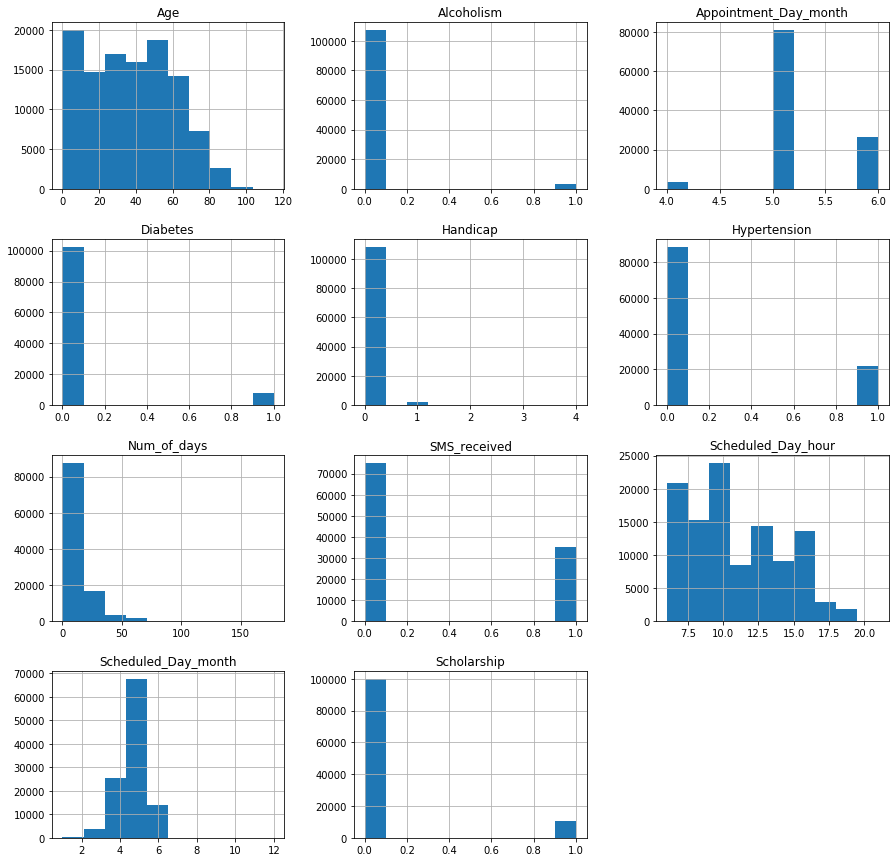

```python
df_copy.hist(figsize = (15, 15));
```

### Question 1 - What gender (M/F) is most likely to not attend an appointment?

Calculate split by gender

```python
# Of the total sample, what proportion is M/F?
gender = df_copy['Gender'].value_counts()
prop_female = round((gender['F']/gender.sum())*100, 2)
prop_male = round((gender['M']/gender.sum())*100, 2)
```

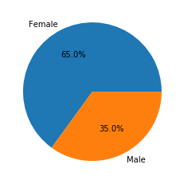

```python
# Show the split in a pie chart:
labels = "Female", "Male"
sizes = [prop_female, prop_male]
fig1, ax1 = plt.subplots()
ax1.pie(sizes, labels=labels, autopct='%1.1f%%');
```

The proportion of female patients is 65% and the proportion of male patients is 35%.

```python
# Of this, how many Males and Females are no-shows?
gender_groupby = df_copy.groupby(['No_show', 'Gender']).No_show.count()
gender_groupby
```

```
No_show  Gender
No       F         57245
         M         30962
Yes      F         14594
         M          7725
Name: No_show, dtype: int64
```

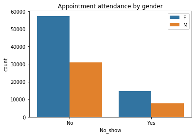

```python
# Plot the appointment attendance:
sns.countplot(x = df_copy['No_show'], hue = df_copy['Gender'], data =df_copy)
plt.legend()
plt.title("Appointment attendance by gender")
plt.figure(figsize = (15, 15));
```

Looking at the proportion of missed appointments by gender:

```python
# Calculate proprtion of missed appointments by gender:
no_show_gender = df[df_copy['No_show'] == "Yes"].groupby(['Gender']).size()
tot_gender = df_copy.groupby(['Gender']).size()
prop_gender = round((no_show_gender/tot_gender)*100, 1)
prop_gender
```

```
Gender
F    20.3
M    20.0
dtype: float64
```

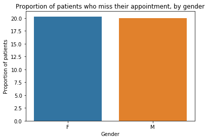

```python
# Plot the proportions:
sns.barplot(x = prop_gender.index, y = prop_gender)
plt.title("Proportion of patients who miss their appointment, by gender")
plt.ylabel("Proportion of patients")
plt.xlabel("Gender");
```

#### Question 1 observations:

- Of the 110,526 records, 65% of our patients are female and 35% are male.
- From a patient count perspective, females have a higher missed appointment count, however this is due to a higher female patient database.
- Looking at the proportion of patients who miss appointments, both genders are quite similar at approximately 20%, indicating that there is no particular gender who is likely to miss a scheduled appointment.

### Question 2 - How does age affect whether a patient will turn up to an appointment?

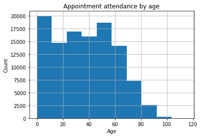

```python
# Plot the age on a histogram:
df_copy['Age'].hist()
plt.xlabel("Age")
plt.ylabel("Count")
plt.title("Appointment attendance by age");
```

Observations: The graph above shows the data skewed to the right, indicating that we have fewer patients who are of an older age category.

Looking at the age data based on the age groups created

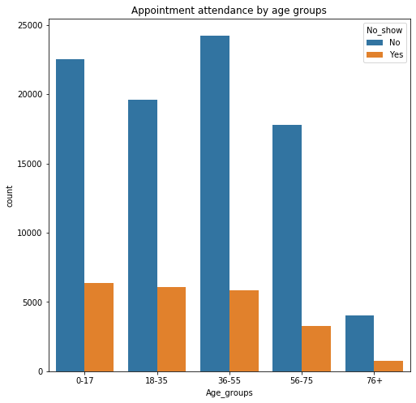

```python
# Looking at this in the age groups we created:
plt.figure(figsize = (8, 8))
sns.countplot(x = df['Age_groups'], hue = df['No_show'])
plt.title("Appointment attendance by age groups");
```

Looking at the proportion of missed appointments by age groups

```python
# Calculate proprtion of missed appointments by age groups:
no_show_age = df[df_copy['No_show'] == "Yes"].groupby(['Age_groups']).size()
tot_age = df_copy.groupby(['Age_groups']).size()
prop_age = round((no_show_age/tot_age)*100, 1)
prop_age
```

```
Age_groups
0-17     22.0
18-35    23.7
36-55    19.4
56-75    15.5
76+      16.2
dtype: float64
```

Plotting this on a bar chart:

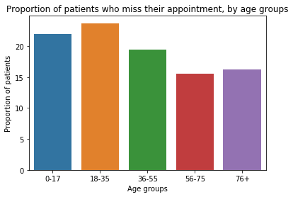

```python
# Plot the proportion of missed appointments by age groups:
sns.barplot(x = prop_age.index, y = prop_age)
plt.title("Proportion of patients who miss their appointment, by age groups")
plt.ylabel("Proportion of patients")
plt.xlabel("Age groups");
```

### Question 3 - What impact does the location of the hospital have on appointment attendance?

Look at the distribution of attendance on a chart

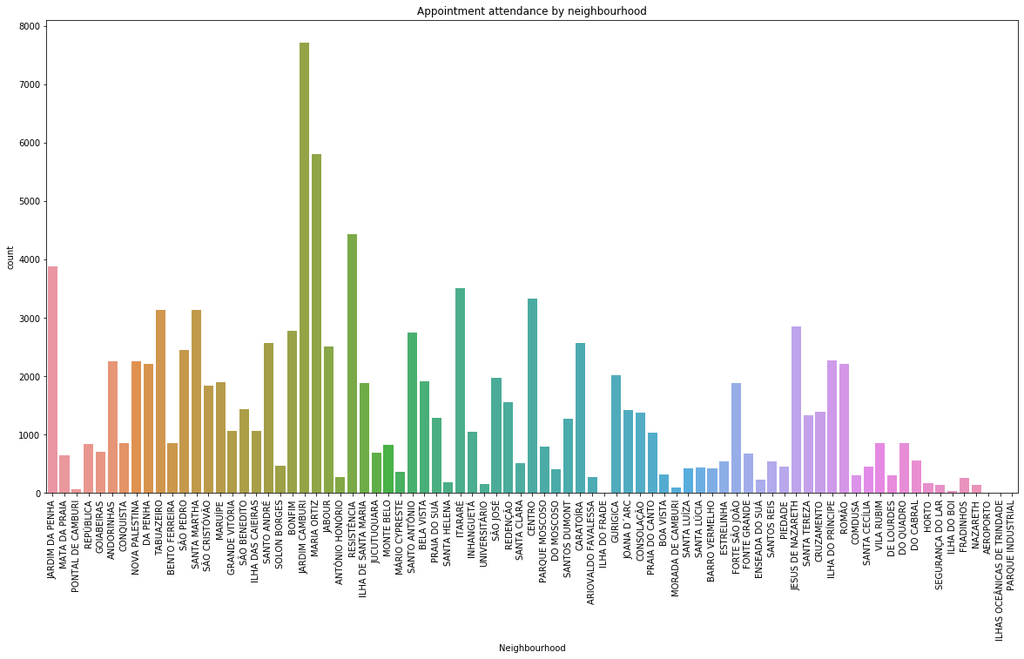

```python
# Plot attendance by neighbourhood:
plt.figure(figsize = (20, 10))
sns.countplot(x = df_copy['Neighbourhood'])
plt.title("Appointment attendance by neighbourhood")
plt.xticks(rotation=90);
```

The graph above is has a lot of data as there are 81 neighbourhoods!  
It might be better to review the proportion of missed appointments by location

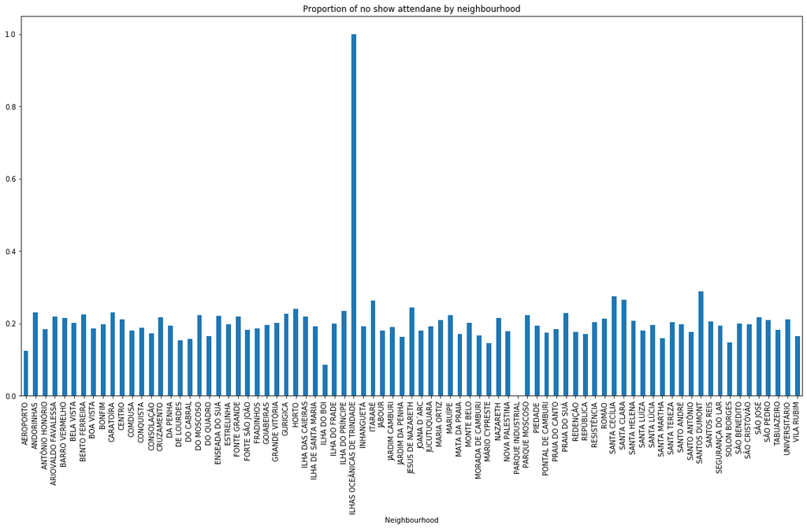

```python
# review the proportion of missed appointment by location:
prop_neighbourhood = df_copy.query('No_show == "Yes"').groupby('Neighbourhood').size()/df_copy.groupby('Neighbourhood').size()
plt.figure(figsize = (20, 10))
prop_neighbourhood.plot(kind = 'bar')
plt.title("Proportion of no show attendane by neighbourhood");
```

Observations:

- It is evident from the above that the there is one neighbourhood that has a significantly higher proportion of no shows than others - Ilhas Oceanicas de Trindade.
- We can also see that there is one neighbourhood that a ratio of 0.

Investigating why there are two outlier neighbourhoods:

```python
# Investigating the above further:
df_copy['Neighbourhood'].value_counts()
```

```
JARDIM CAMBURI                 7717
MARIA ORTIZ                    5805
RESISTÊNCIA                    4431
JARDIM DA PENHA                3877
ITARARÉ                        3514
                               ...
ILHA DO BOI                      35
ILHA DO FRADE                    10
AEROPORTO                         8
ILHAS OCEÂNICAS DE TRINDADE       2
PARQUE INDUSTRIAL                 1
Name: Neighbourhood, Length: 81, dtype: int64
```

Further investigation into ILHAS OCEÂNICAS DE TRINDADE:

```python
df_copy.query('Neighbourhood == "ILHAS OCEÂNICAS DE TRINDADE"')
```

|  | Gender | ScheduledDay | AppointmentDay | Age | Neighbourhood | Scholarship | Hypertension | Diabetes | Alcoholism | Handicap | SMS_received | No_show | Scheduled_Day_month | Scheduled_Day_dow | Scheduled_Day_hour | Appointment_Day_month | Appointment_Day_dow | Num_of_days | Num_of_days_groups | Age_groups |
| --- | --- | --- | --- | --- | --- | --- | --- | --- | --- | --- | --- | --- | --- | --- | --- | --- | --- | --- | --- | --- |
| 48754 | F | 2016-04-14 12:25:43+00:00 | 2016-05-13 00:00:00+00:00 | 51 | ILHAS OCEÂNICAS DE TRINDADE | 0 | 0 | 0 | 0 | 0 | 0 | Yes | 4 | Thursday | 12 | 5 | Friday | 28 | 1_month | 36-55 |
| 48765 | F | 2016-04-14 12:26:13+00:00 | 2016-05-13 00:00:00+00:00 | 58 | ILHAS OCEÂNICAS DE TRINDADE | 0 | 0 | 0 | 0 | 0 | 0 | Yes | 4 | Thursday | 12 | 5 | Friday | 28 | 1_month | 56-75 |

We can see the reason for the outliers is because for ILHAS OCEÂNICAS DE TRINDADE, there is only a sample of 2. With both samples having a 'Yes' under the 'No_show' column, this has resulted in 100% no show attendance for that neighbourhood.

Further investigation into PARQUE INDUSTRIAL:

```python
df_copy.query('Neighbourhood == "PARQUE INDUSTRIAL"')
```

|  | Gender | ScheduledDay | AppointmentDay | Age | Neighbourhood | Scholarship | Hypertension | Diabetes | Alcoholism | Handicap | SMS_received | No_show | Scheduled_Day_month | Scheduled_Day_dow | Scheduled_Day_hour | Appointment_Day_month | Appointment_Day_dow | Num_of_days | Num_of_days_groups | Age_groups |
| --- | --- | --- | --- | --- | --- | --- | --- | --- | --- | --- | --- | --- | --- | --- | --- | --- | --- | --- | --- | --- |
| 75199 | F | 2016-05-05 10:48:59+00:00 | 2016-05-05 00:00:00+00:00 | 17 | PARQUE INDUSTRIAL | 0 | 0 | 0 | 0 | 0 | 0 | No | 5 | Thursday | 10 | 5 | Thursday | 0 | same_day | 0-17 |

Similarly, with PARQUE INDUSTRIAL, there is a sample size of 1 which is not a no show, resulting in 0%.

#### Question 3 observations:

- There are 81 neighbourhoods in the dataset.
- Of these, there are 2 neighbourhoods we have identified that are outliers and should be removed from the dataset if we are to continue using neighbourhood as a field in further predictive analytics. Not removing it could lead to further bias.

### Question 4 - How does the number of days between making an appointment to the scheduled date, affect attendance?

First, look at the statistics:

```python
# What is the average number of days someone has to wait between making an appointment and the scheduled date?
df['Num_of_days'].describe()
```

```
count    110526.000000
mean          9.532915
std          15.027724
min           0.000000
25%           0.000000
50%           3.000000
75%          14.000000
max         178.000000
Name: Num_of_days, dtype: float64
```

From the above, we can see the mean number of days is 9.5 days between making an appointment and the scheduled date.

Count the number in each age group

```python
# Count the number in each age group:
df_copy.groupby('Num_of_days_groups').count().iloc[:, 0]
```

```
Num_of_days_groups
same_day    43775
1_week      29309
2_weeks     11196
1_month     16540
3_months     9545
6_months      161
Name: Gender, dtype: int64
```

Plotting this on a chart:

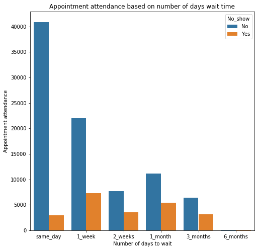

```python
# Plot the age groups by appointment attendance:
plt.figure(figsize = (8, 8))
sns.countplot(x = df_copy['Num_of_days_groups'], hue = df_copy['No_show'])
plt.title("Appointment attendance based on number of days wait time", size=12)
plt.xlabel("Number of days to wait")
plt.ylabel("Appointment attendance");
```

Looking at the proportion of missed appointments by wait time

```python
# Calculate proprtion of missed appointments by wait time:
no_show_days = df[df_copy['No_show'] == "Yes"].groupby(['Num_of_days_groups']).size()
tot_days = df_copy.groupby(['Num_of_days_groups']).size()
prop_days = round((no_show_days/tot_days)*100, 1)
prop_days
```

```
Num_of_days_groups
same_day     6.6
1_week      25.0
2_weeks     31.2
1_month     32.5
3_months    33.1
6_months    27.3
dtype: float64
```

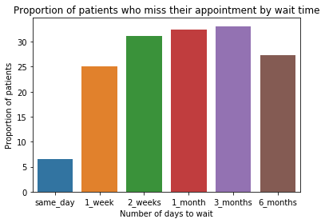

```python
# Plot the proportion of missed appointments by age groups:
sns.barplot(x = prop_days.index, y = prop_days)
plt.title("Proportion of patients who miss their appointment by wait time")
plt.ylabel("Proportion of patients")
plt.xlabel("Number of days to wait");
```

#### Question 4 observations:

- We can see from the above that the majority of appointments are made on the same day of the visit.
- Although the majority of scheduled appointments occur on the same day, approximately 7% of patients do not turn up.
- The highest count of no show appoinments occur when there is a 7 day wait.
- Very few patients will make an appointment more than 6 months in advance.
- Proportionally, patients who make an appointment 3 months in advance have the highest missed appointment rate at approximately 33%.
- This decreases to 27% for patients who made an appointment 6 months in advance.

### Question 5 - How effective are SMS reminders?

Calculate how many patients received a SMS reminder

```python
# Calculate sum of SMS messages that were received:
sms_rec = df_copy['SMS_received'].sum()
sms_rec
```

```
35482
```

```python
# Calculate total number of records in SMS_received column:
sms_tot = df_copy['SMS_received'].value_counts().sum()
sms_tot
```

```
110526
```

```python
# Calculate proportion of SMS messages that were received:
prop_sms = round((sms_rec/sms_tot)*100, 2)
prop_sms

print("The percentage of patients who received a SMS reminder is {}%".format(prop_sms))
```

```
The percentage of patients who received a SMS reminder is 32.1%
```

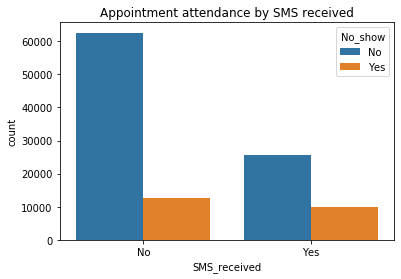

```python
# Plot the count of appointment attendance vs SMS received
sms = sns.countplot(x = df_copy['SMS_received'], hue = df_copy['No_show'])
x_ticks_labels=['No', 'Yes']
sms.set_xticklabels(x_ticks_labels)
sms.set_title("Appointment attendance by SMS received");
```

Calculate the proportion of patients who received a SMS but missed their appointment:

```python
# Calculating the proportion of patients who received a SMS but did not attend their appointment:
no_show_sms = df[df_copy['No_show'] == "Yes"].groupby(['SMS_received']).size()
tot_sms = df_copy.groupby(['SMS_received']).size()
no_show_sms_prop = round((no_show_sms/tot_sms)*100, 1)
no_show_sms_prop
```

```
SMS_received
0    16.7
1    27.6
dtype: float64
```

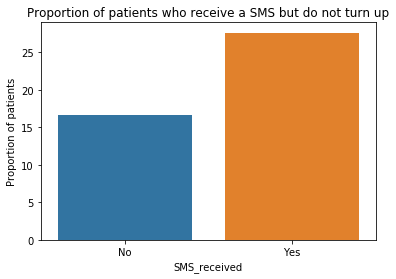

```python
# Plot the proportion on a graph:

no_show_sms = sns.barplot(x = no_show_sms_prop.index, y = no_show_sms_prop)
no_show_sms.set_xticklabels(x_ticks_labels)
plt.title("Proportion of patients who receive a SMS but do not turn up")
plt.ylabel("Proportion of patients");
```

```python
print("Of the {}% of patients who received a SMS reminder, {}% still did not turn up to their appointment.".format(prop_sms, no_show_sms_prop[1]))
```

```
Of the 32.1% of patients who received a SMS reminder, 27.6% still did not turn up to their appointment.
```

Look further into this, and see if there is a correlation between not turning up for an appointment and the number of days between making an appointment and scheduled day

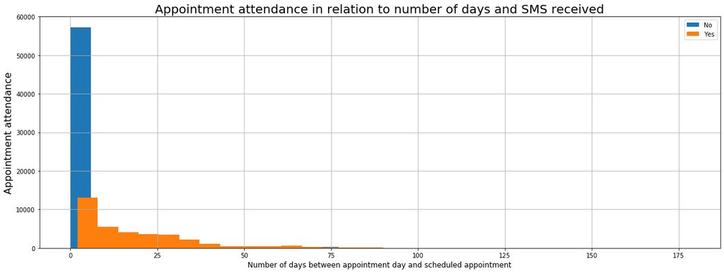

```python
plt.figure(figsize=(20,7))
df_copy.groupby('SMS_received')['Num_of_days'].hist(bins=30)
plt.legend(df_copy['No_show'].unique())
plt.xlabel("Number of days between appointment day and scheduled appointment", size = 12)
plt.ylabel("Appointment attendance", size = 16)
plt.title("Appointment attendance in relation to number of days and SMS received", size =20);
```

#### Question 5 observations:

- From a total of 110,526 appointments, 35,482 SMS reminders were sent out, approximately 32%.
- Of the patients that received SMS reminders, approximately 27% of patients did not turn up to their appointment.
- Patients who miss their appointment have a longer wait time between the day the appointment was made and the scheduled day.

### Question 6 - How does day of the week affect attendance?

Review the total count of visits by day of the week

```python
df_copy['Scheduled_Day_dow'].value_counts()
```

```
Tuesday      26168
Wednesday    24262
Monday       23084
Friday       18915
Thursday     18073
Saturday        24
Name: Scheduled_Day_dow, dtype: int64
```

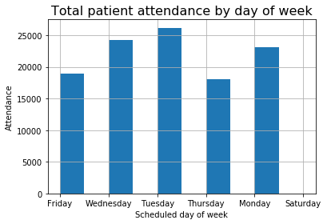

```python
# Look at the counts by day of the week
df_copy['Scheduled_Day_dow'].hist()
plt.title("Total patient attendance by day of week", size=16)
plt.xlabel("Scheduled day of week")
plt.ylabel("Attendance");
```

Observations:

#### Looking at the days of the week by appointment attendance.

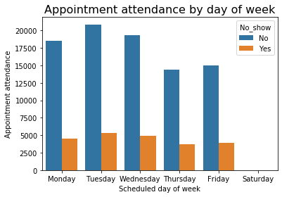

```python
# Plot the no show appointments against the scheduled day of the week:
sns.countplot(x = df_copy['Scheduled_Day_dow'], hue = df_copy['No_show'], order=['Monday', 'Tuesday', 'Wednesday', 'Thursday', 'Friday', 'Saturday'])
plt.title("Appointment attendance by day of week", size=16)
plt.xlabel("Scheduled day of week")
plt.ylabel("Appointment attendance");
```

```python
# Proportion of missed appointments by day of week:
no_show_dow = df[df_copy['No_show'] == "Yes"].groupby(['Scheduled_Day_dow']).size()
tot_dow = df_copy.groupby(['Scheduled_Day_dow']).size()
prop_dow = round((no_show_dow/tot_dow)*100, 1)
prop_dow
```

```
Scheduled_Day_dow
Friday       20.5
Monday       19.8
Saturday      4.2
Thursday     20.5
Tuesday      20.2
Wednesday    20.1
dtype: float64
```

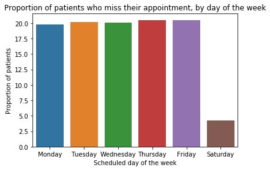

```python
# Plot the proportion of missed appointments by day of week:
x_dow_ticks_labels=['Monday', 'Tuesday', 'Wednesday', 'Thursday', 'Friday', 'Saturday']
prop_dow = sns.barplot(x = prop_dow.index, y = prop_dow, order=['Monday', 'Tuesday', 'Wednesday', 'Thursday', 'Friday', 'Saturday'])
prop_dow.set_xticklabels(x_dow_ticks_labels)
plt.title("Proportion of patients who miss their appointment, by day of the week")
plt.ylabel("Proportion of patients")
plt.xlabel("Scheduled day of the week");
```

#### Question 6 observations:

- Saturday appears to be an outlier with approximately 4% of patients missing their appointment.
- All other days have a missed appointment proportion of approximately 20%.
- On further investigation, Saturday only has a total of 24 appointments, with only 1 missed appointment which is causing this to be an outlier.
- If we were to use day of the week in further predictive analytics, we might want to exclude Saturday from the scheduled day of the week as an indicator as it may lead to bias.
- There are no Sunday appointments.

## 5. Conclusions

From the dataset available and analysis performed, the following conclusions can be made:

- Gender does not appear to affect whether a patient will turn up to an appointment. While the dataset was approximately 65% female, the same proportion of males and females are likely to miss an appointment (approximately 20%).
- The proportion of missed appointments is highest amongst the 18-35 year old age group at 24%. This could be perhaps they are busy at school, University, work or taking care of their family.
- The location of the hospital/medical centre does not appear to significantly affect attendance.
- The number of days between when the appointment is made and the scheduled date appears to be the most indicative. For appointments made on the same day, it is highly likely the patient will turn up. Most likely because it may be an urgent appointment. Appointments made more than 7 days in advance have a high proportion of no-shows, either the patient forgot, or no longer needs to see a doctor and forgot to cancel the appointment.
- Of the SMS reminders sent out to patients, approximately 27% of patients still missed their appointment.
- The day of the week does not appear to affect attendance.

Limitations:

- The dataset is only limited to a portion of the year. To gain further insights, it would be better to have a dataset over a year to see if there are any seasonal trends and to provide a larger dataset.
- The dataset could include further information on patients (eg: highest education, annual household income)
- The dataset could include further information on the hospital/medical centre (eg: price, region, social-economic factors).

## 6. References

- https://stackoverflow.com/questions/45273731/binning-column-with-python-pandas
- https://pandas.pydata.org/pandas-docs/stable/reference/api/pandas.to_datetime.html
- https://www.geeksforgeeks.org/python-pandas-series-dt-month/
- https://pandas.pydata.org/pandas-docs/stable/reference/api/pandas.Series.dt.day_name.html
- https://stackoverflow.com/questions/56380949/find-absolute-difference-between-2-columns-with-dates-of-different-formats-as-nu
- https://matplotlib.org/3.1.1/gallery/pie_and_polar_charts/pie_features.html#sphx-glr-gallery-pie-and-polar-charts-pie-features-py
- https://seaborn.pydata.org/generated/seaborn.countplot.html
- https://stackoverflow.com/questions/47741400/pandas-dataframe-group-and-sort-by-weekday